# Milestone Report - Technical Version

Jiří Palek

12/29/2015

## Introduction

Natural Language Processing (NLP) is a rapidly growing area using computer science, mathematics and linguistics to handle text data. NLP is very important especially with processing dozens of text sources on the internet and to help people interact with computers.

The latter is the main topic of this project. The goal is to help the users to write computer texts with predictive text mining application, more precisely, to create a Shiny app that takes as input a phrase (multiple words) and predicts the next word.

This article is about introductory exploratory analysis and strategy hints.

**Note:** This is a technical version of the text with all R code. For the version without code chunks see *Milestone Report - Manager Version.*

## Data and Goal

The data originally comes from HC Corpora. The readme file can be seen [here](http://www.corpora.heliohost.org/aboutcorpus.html). The [training data](https://d396qusza40orc.cloudfront.net/dsscapstone/dataset/Coursera-SwiftKey.zip) for Capstone Project was provided via course pages.

The data for each language consists of three files which contain text data from

- blogs,
- news, and
- Twitter.

Only the English files are used for analysis.

```r
#addresses
  adrBlogs<-"D:/===KURZY===/DS10/=RData=/en_US.blogs.txt"
  adrNews<-"D:/===KURZY===/DS10/=RData=/en_US.news.txt"
  adrTwitter<-"D:/===KURZY===/DS10/=RData=/en_US.twitter.txt"

#data rading
  blogs<-file(adrBlogs,open="rb")
  blogs<-readLines(blogs,encoding="UTF-8",skipNul=TRUE)

  news<-file(adrNews,open="rb")
  news<-readLines(news,encoding="UTF-8",skipNul=TRUE)

  twitter<-file(adrTwitter,open="rb")
  twitter<-readLines(twitter,encoding="UTF-8",skipNul=TRUE)

#data saving
  save(blogs,file="D:/===KURZY===/DS10/=RData=/blogs.RData")
    save(news,file="D:/===KURZY===/DS10/=RData=/news.RData")
    save(twitter,file="D:/===KURZY===/DS10/=RData=/twitter.RData")
```

**Technical Note:** The files were unzipped and saved on the local drive. As will be showen in the following text, handling these files is time consuming due to their size. That is why the files are saved as variables *blogs*, *news*, and *twitter* after reading and the furhter analysis starts with loading these variables instead of the files.

```r
  #data loading
    load("D:/===KURZY===/DS10/=RData=/blogs.RData")
    load("D:/===KURZY===/DS10/=RData=/news.RData")
    load("D:/===KURZY===/DS10/=RData=/twitter.RData")
```

## Basic Files Summary

The table below shows basic information about all three files. The goal is to create an online app and so the base data used for prediction have to be as small as possible; for shiny app it is 512 MB. That is why **only the relevant data have to be chosen**.

| File Name | Size in R | Number of Lines | Max Length of Line |
| --- | --- | --- | --- |
| en_US.blogs.txt | 261 MB | 899 288 | 40 833 |
| en_US.news.txt | 262 MB | 1 010 242 | 11 384 |
| en_US.twitter.txt | 316 MB | 2 360 148 | 140 |

## Sentences

First of all, the relevant data structure for text prediction have to be chosen. The lines of data do not represent any meaningful structure. There are blog parts in the first data set, news in the second data set and tweets in the third data set. They do not correspond to each other.

At this point the unified approach has to be stated. It is not reasonable to have a long series of words for next word prediction. The hypothesis is, that **only from two to five word segments should be appropriate**. That is why shorter text structure shall be used. The **sentence** seems to be the good one.

Another reason for transforming all data to sentences is that the **words order differs with respect to the basic sentence type** (declarative, interrogative, and imperative). The distribution of these types should be studied and reflected.

**Technical Note:** The conversion of *blogs* variable into sentences took 20 hours. The other variables *news* and *twitter* were not processed yet, so the following part contains only results about *blogs* data.

```r
#sentence cration -------------------------------------------------------------
  library(NLP)
  library(openNLP)
  library(RWeka)
  library(magrittr)
  library(tictoc)

    X<-blogs

    sentenceAnnotator <- Maxent_Sent_Token_Annotator()
    a<-tic()
    sent<-NULL
    for (i in 1:length(X)){
        division <- annotate(X[i], list(sentenceAnnotator))

        for (j in 1:length(division))
            sent[length(sent)+1]<-substr(
                    X[i],
                    start=division[[j]]$start,
                    stop=division[[j]]$end)

        if (i %% round(length(X)/50) ==0){
            print(i/length(X))
        }
    }
    b<-toc()

    blogsSent<-sent
    save(blogsSent,
            file="D:/===KURZY===/DS10/=RData=/blogsSent.RData")
```

```r
  library(ggplot2)
  multiplot <- function(..., plotlist=NULL, file, cols=1, layout=NULL) {
    #http://www.cookbook-r.com/Graphs/Multiple_graphs_on_one_page_(ggplot2)/
    library(grid)

    # Make a list from the ... arguments and plotlist
    plots <- c(list(...), plotlist)

    numPlots = length(plots)

    # If layout is NULL, then use 'cols' to determine layout
    if (is.null(layout)) {
      # Make the panel
      # ncol: Number of columns of plots
      # nrow: Number of rows needed, calculated from # of cols
      layout <- matrix(seq(1, cols * ceiling(numPlots/cols)),
                       ncol = cols, nrow = ceiling(numPlots/cols))
    }

    if (numPlots==1) {
      print(plots[[1]])

    } else {
      # Set up the page
      grid.newpage()
      pushViewport(viewport(layout = grid.layout(nrow(layout), ncol(layout))))

      # Make each plot, in the correct location
      for (i in 1:numPlots) {
        # Get the i,j matrix positions of the regions that contain this subplot
        matchidx <- as.data.frame(which(layout == i, arr.ind = TRUE))

        print(plots[[i]], vp = viewport(layout.pos.row = matchidx$row,
                                        layout.pos.col = matchidx$col))
      }
    }
  }
```

```r
  #loading data for analysis
  load("D:/===KURZY===/DS10/=RData=/blogsSent.RData")

  #setting base variable "sentences" for analysis
  #the folowing code use it for all graphs and analysis
  sentences<-blogsSent
  dataSource<-"Blogs"
```

First, the distribution of the sentence type was studied. The division was based on the last symbol of the sentence. As can be seen from the following figure, fist three classes corresponds to “.”, “!”, and “?”.

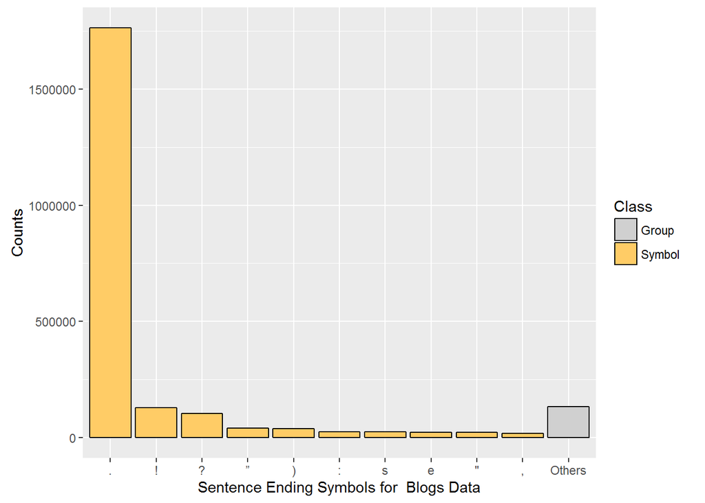

```r
#FIGURE -----------------------------------------------------------------------

  sentencesEnds<-substr(sentences,nchar(sentences),nchar(sentences))
  groups<-rev(sort(table(sentencesEnds),desending=TRUE))

  barTable<-data.frame(matrix(rep(0,11*3),ncol=3))
  names(barTable)<-c("Symbol","Counts","Class")
  barTable[1:10,1]<-names(groups[1:10])
  barTable[1:10,2]<-groups[1:10]
  barTable[1:10,3]<-"Symbol"
  barTable[11,1]<-"Others"
  barTable[11,2]<-sum(groups[11:length(groups)])
  barTable[11,3]<-"Group"
  barTable<-within(barTable,Symbol<-factor(Symbol,levels=barTable$Symbol))

  #plotting
  ggplot(barTable, aes(x=Symbol, y=Counts, fill=Class)) +
    geom_bar(stat="identity", colour="black") +
    scale_fill_manual(values=c("#d0d0d0", "#FFCC66")) +
    xlab(paste("Sentence Ending Symbols for ",dataSource,"Data"))
```

Second important aspect is the length of the sentences. The maximal length of sentence in symbols is 3948. This is not meaningful and more investigation is needed.

The following figures show histograms of the length of the sentences in symbols for all *blogs* data and three interesting types of sentences (ended with “.”, “!”, and “?”). The counts are decreasing exponentially, and therefore the histograms are two for each class; one for 1-500 symbols and one for more than 500 symbols.

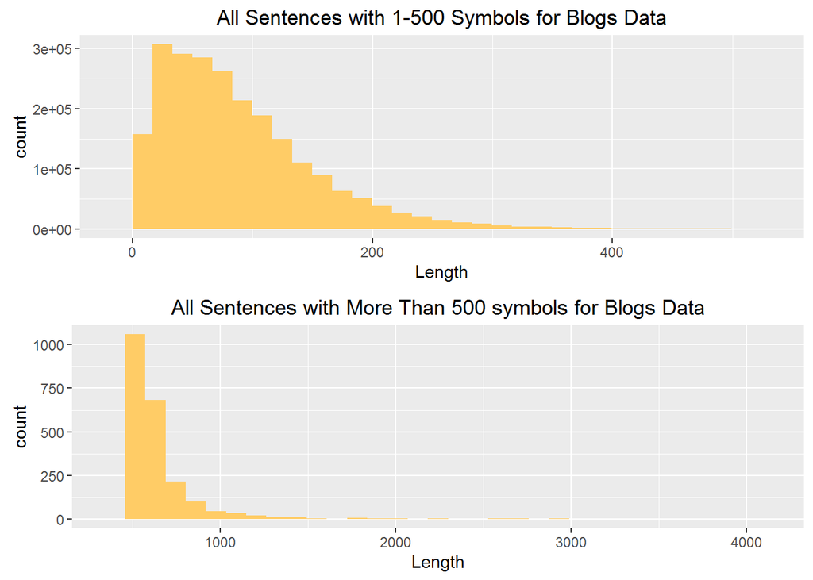

```r
#FIGURE -----------------------------------------------------------------------

  #all data
  sentencesLengths<-data.frame(nchar(sentences))
  names(sentencesLengths)<-"Length"

  #histograms
  pom<-subset(sentencesLengths,Length<=500)
  p1<-ggplot(pom, aes(x=Length)) +
        geom_histogram(fill="#FFCC66", bins = 30) +
        ggtitle(paste("All Sentences with 1-500 Symbols for",
                                dataSource,"Data"))

  pom<-subset(sentencesLengths,Length>500)
  p2<-ggplot(pom, aes(x=Length)) +
        geom_histogram(fill="#FFCC66", bins = 30) +
        ggtitle(paste("All Sentences with More Than 500 symbols for",
                                dataSource,"Data"))
  multiplot(p1, p2, cols=1)
```

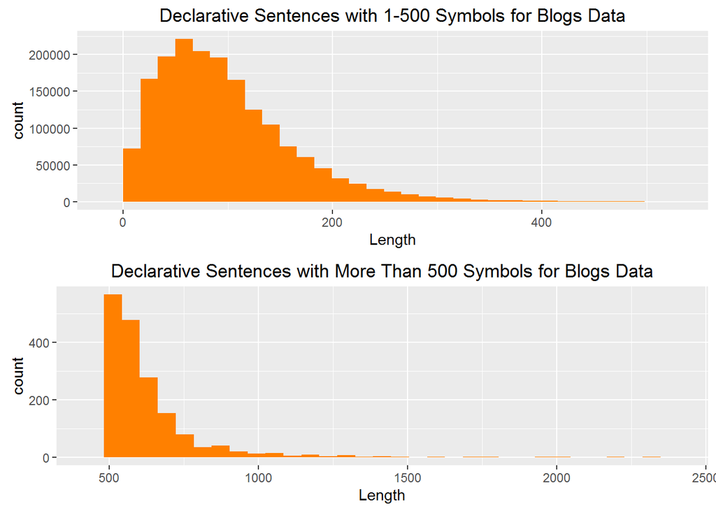

```r
#FIGURE -----------------------------------------------------------------------

  #Declarative Sentences
  sentencesLengths<-data.frame(nchar(sentences[sentencesEnds=="."]))
  names(sentencesLengths)<-"Length"

  #histograms
    pom<-subset(sentencesLengths,Length<=500)
    p1<-ggplot(pom, aes(x=Length)) +
      geom_histogram(fill="#ff8000", bins = 30) +
      ggtitle(paste("Declarative Sentences with 1-500 Symbols for",
                                    dataSource,"Data"))

    pom<-subset(sentencesLengths,Length>500)
    p2<-ggplot(pom, aes(x=Length)) +
      geom_histogram(fill="#ff8000", bins = 30) +
      ggtitle(paste("Declarative Sentences with More Than 500 Symbols for",
                                    dataSource,"Data"))
    multiplot(p1, p2, cols=1)
```

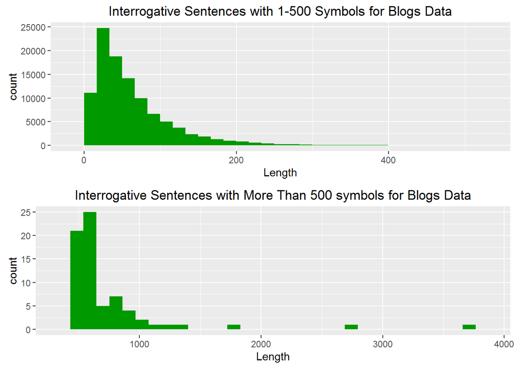

```r
#FIGURE -----------------------------------------------------------------------

  #Interrogative Sentences
  sentencesLengths<-data.frame(nchar(sentences[sentencesEnds=="?"]))
  names(sentencesLengths)<-"Length"

  #histograms
    pom<-subset(sentencesLengths,Length<=500)
    p1<-ggplot(pom, aes(x=Length)) +
      geom_histogram(fill="#009900", bins = 30) +
      ggtitle(paste("Interrogative Sentences with 1-500 Symbols for",
                                    dataSource,"Data"))

    pom<-subset(sentencesLengths,Length>500)
    p2<-ggplot(pom, aes(x=Length)) +
      geom_histogram(fill="#009900", bins = 30) +
      ggtitle(paste("Interrogative Sentences with More Than 500 symbols for",
                                    dataSource,"Data"))
    multiplot(p1, p2, cols=1)
```

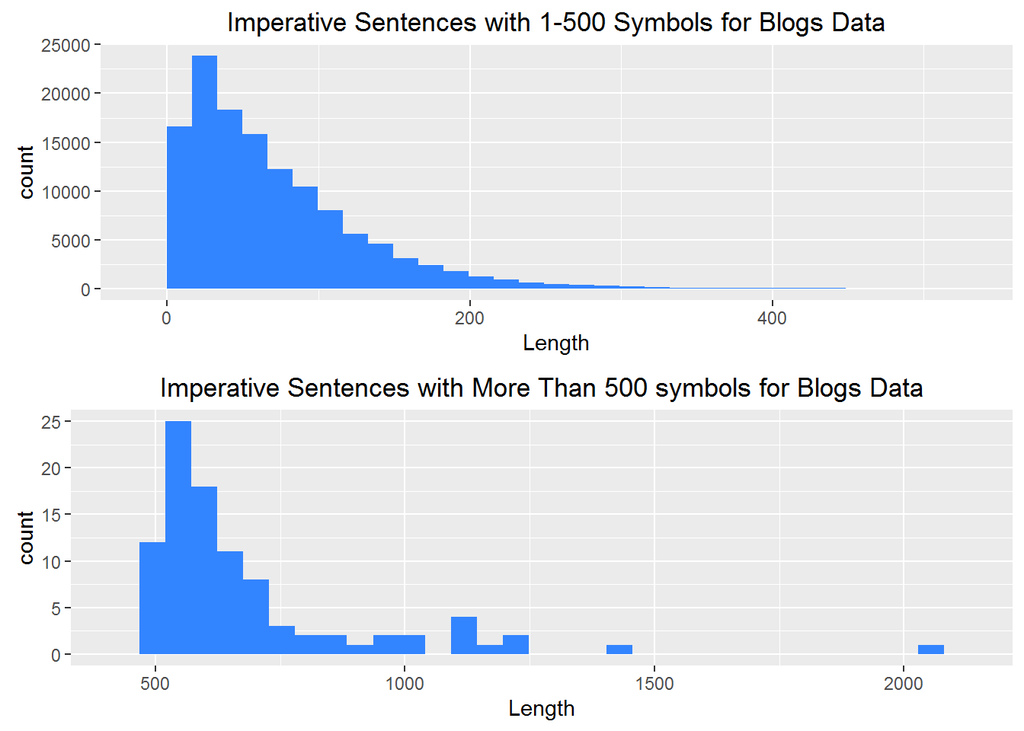

```r
#FIGURE -----------------------------------------------------------------------

  #Imperative Sentences
  sentencesLengths<-data.frame(nchar(sentences[sentencesEnds=="!"]))
  names(sentencesLengths)<-"Length"

  #histograms
    pom<-subset(sentencesLengths,Length<=500)
    p1<-ggplot(pom, aes(x=Length)) +
      geom_histogram(fill="#3384ff", bins = 30) +
      ggtitle(paste("Imperative Sentences with 1-500 Symbols for",
                                    dataSource,"Data"))

    pom<-subset(sentencesLengths,Length>500)
    p2<-ggplot(pom, aes(x=Length)) +
      geom_histogram(fill="#3384ff", bins = 30) +
      ggtitle(paste("Imperative Sentences with More Than 500 symbols for",
                                    dataSource,"Data"))
    multiplot(p1, p2, cols=1)
```

**Conclusions:**

- **The data will be transformed to sentences.**
- **Only sentences ended with “.”, “!”, and “?” will be used for further analysis.**
- **The length of sentences used for prediction will be limited to 200 symbols.**
- **The prediction will be tested for the sentence types “.”, “!”, and “?” together and separately.**

## Words

As was mentioned before, the goal is to predict next word based on several forgone words, and the base data structure for word sequences will be sentence.

At this point it is necessary to do some exploratory analysis of the words and their distribution. Following setting is used for words creation:

- conversion to lower,
- removing number,
- removing punctuation,
- removing separators,
- removing twitter specific symbols,
- removing hyphens,
- NOT removing stopwords.

The same setting will be used for pre-processing the given words in prediction.

```r
library(quanteda)

#loading data
    load("D:/===KURZY===/DS10/=RData=/blogs.RData")
    load("D:/===KURZY===/DS10/=RData=/news.RData")
    load("D:/===KURZY===/DS10/=RData=/twitter.RData")

#joining data
    allDataInText<-c(paste(blogs,collapse=" "),
                                 paste(news,collapse=" "),
                                 paste(twitter,collapse=" "))

#tokenizing
    wordsAllData<-dfm(allDataInText,
            verbose = TRUE,
            toLower = TRUE,
            removeNumbers=TRUE,
            removePunct=TRUE,
            removeSeparators=TRUE,
            removeTwitter=TRUE,
            removeHyphens=TRUE,
            stem = FALSE,
            language = "english",
            ngrams=1)

#saving
    save(wordsAllData,file="D:/===KURZY===/DS10/=RData=/wordsAllData.RData")
```

```r
library(quanteda)

#loading
    load("D:/===KURZY===/DS10/=RData=/wordsAllData.RData")

  allWords<-sort(colSums(wordsAllData),decreasing=TRUE)
```

The total number of words in all three files is 100 644 862 and their distribution can be shown with wordcloud figure; 150 words with highest frequencies is used. The data seems reasonable, because the top words are **stopwords**, which are very important in this task and they are **not removed**.

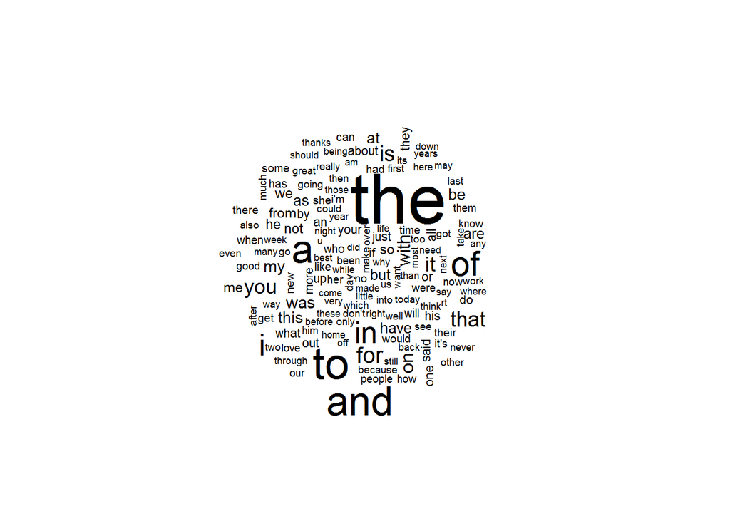

```r
#FIGURE -----------------------------------------------------------------------
    library(wordcloud)

    cloud<-data.frame(Word=names(allWords)[1:200],Count=allWords[1:200])
    wordcloud(cloud$Word, cloud$Count, max.words=150)
```

The more detail description shows the last figure, which contained distribution of twenty top words for each of file type.

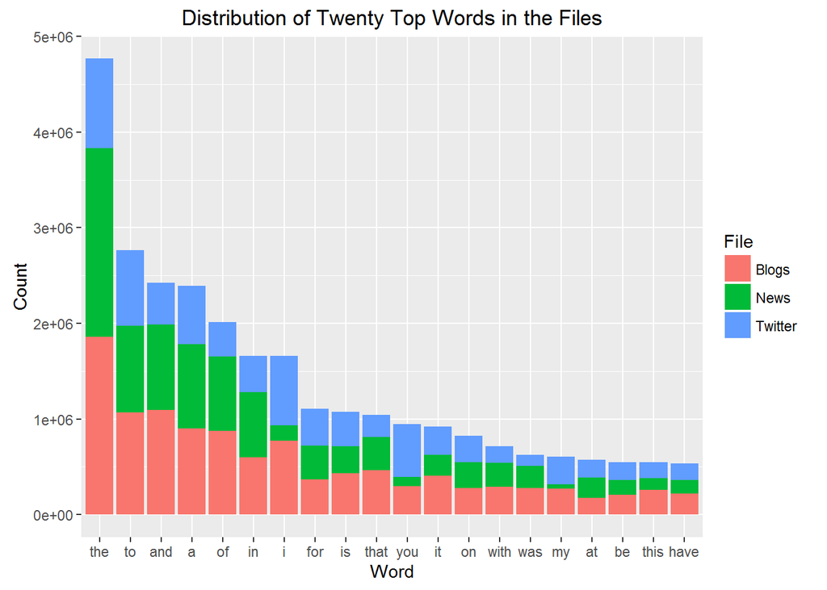

```r
    p<-20
    vyber<-as.data.frame(wordsAllData[,names(allWords)[1:p]])

    vyber2<-data.frame(
            Word=rep(names(vyber),3),
            File=c(rep("Blogs",p),rep("News",p),rep("Twitter",p)),
            Count=c(as.integer(vyber[1,]),as.integer(vyber[2,]),as.integer(vyber[3,])))
    vyber2<-within(vyber2,Word<-factor(Word,levels=names(vyber)))

    library(ggplot2)
    ggplot(vyber2, aes(x=Word, y=Count, fill=File)) +
            geom_bar(stat="identity") +
            ggtitle("Distribution of Twenty Top Words in the Files")
```